# Risk Factor Analysis

## Outcome Variable

**Outcome Variable:** whz

## Predictor Variables

**Intervention Variable:** fhtcm

**Adjustment Set:**

- arm
- W_mage
- W_fage
- meducyrs
- feducyrs
- W_mhtcm
- W_mwtkg
- W_mbmi
- single
- delta_W_mage
- delta_W_fage
- delta_meducyrs
- delta_feducyrs
- delta_W_mhtcm
- delta_W_mwtkg
- delta_W_mbmi
- delta_single

## Stratifying Variables

The analysis was stratified on these variable(s):

- agecat
- studyid
- country

## Data Summary

| agecat | studyid | country | fhtcm | n_cell | n |
| --- | --- | --- | --- | --- | --- |
| Birth | ki1000304b-SAS-CompFeed | INDIA | >=167 cm | 312 | 657 |
| Birth | ki1000304b-SAS-CompFeed | INDIA | <162 cm | 159 | 657 |
| Birth | ki1000304b-SAS-CompFeed | INDIA | [162-167) cm | 186 | 657 |
| Birth | ki1101329-Keneba | GAMBIA | >=167 cm | 4 | 8 |
| Birth | ki1101329-Keneba | GAMBIA | <162 cm | 1 | 8 |
| Birth | ki1101329-Keneba | GAMBIA | [162-167) cm | 3 | 8 |
| Birth | ki1119695-PROBIT | BELARUS | >=167 cm | 11684 | 12474 |
| Birth | ki1119695-PROBIT | BELARUS | <162 cm | 168 | 12474 |
| Birth | ki1119695-PROBIT | BELARUS | [162-167) cm | 622 | 12474 |
| Birth | ki1135781-COHORTS | GUATEMALA | >=167 cm | 26 | 192 |
| Birth | ki1135781-COHORTS | GUATEMALA | <162 cm | 112 | 192 |
| Birth | ki1135781-COHORTS | GUATEMALA | [162-167) cm | 54 | 192 |
| 6 months | ki1000304b-SAS-CompFeed | INDIA | >=167 cm | 370 | 807 |
| 6 months | ki1000304b-SAS-CompFeed | INDIA | <162 cm | 193 | 807 |
| 6 months | ki1000304b-SAS-CompFeed | INDIA | [162-167) cm | 244 | 807 |
| 6 months | ki1000304b-SAS-FoodSuppl | INDIA | >=167 cm | 102 | 371 |
| 6 months | ki1000304b-SAS-FoodSuppl | INDIA | <162 cm | 148 | 371 |
| 6 months | ki1000304b-SAS-FoodSuppl | INDIA | [162-167) cm | 121 | 371 |
| 6 months | ki1101329-Keneba | GAMBIA | >=167 cm | 979 | 1510 |
| 6 months | ki1101329-Keneba | GAMBIA | <162 cm | 113 | 1510 |
| 6 months | ki1101329-Keneba | GAMBIA | [162-167) cm | 418 | 1510 |
| 6 months | ki1119695-PROBIT | BELARUS | >=167 cm | 11143 | 11892 |
| 6 months | ki1119695-PROBIT | BELARUS | <162 cm | 156 | 11892 |
| 6 months | ki1119695-PROBIT | BELARUS | [162-167) cm | 593 | 11892 |
| 6 months | ki1135781-COHORTS | GUATEMALA | >=167 cm | 44 | 336 |
| 6 months | ki1135781-COHORTS | GUATEMALA | <162 cm | 198 | 336 |
| 6 months | ki1135781-COHORTS | GUATEMALA | [162-167) cm | 94 | 336 |
| 24 months | ki1101329-Keneba | GAMBIA | >=167 cm | 823 | 1298 |
| 24 months | ki1101329-Keneba | GAMBIA | <162 cm | 96 | 1298 |
| 24 months | ki1101329-Keneba | GAMBIA | [162-167) cm | 379 | 1298 |
| 24 months | ki1119695-PROBIT | BELARUS | >=167 cm | 3388 | 3610 |
| 24 months | ki1119695-PROBIT | BELARUS | <162 cm | 52 | 3610 |
| 24 months | ki1119695-PROBIT | BELARUS | [162-167) cm | 170 | 3610 |
| 24 months | ki1135781-COHORTS | GUATEMALA | >=167 cm | 72 | 532 |
| 24 months | ki1135781-COHORTS | GUATEMALA | <162 cm | 311 | 532 |
| 24 months | ki1135781-COHORTS | GUATEMALA | [162-167) cm | 149 | 532 |

The following strata were considered:

- agecat: 24 months, studyid: ki1101329-Keneba, country: GAMBIA
- agecat: 24 months, studyid: ki1119695-PROBIT, country: BELARUS
- agecat: 24 months, studyid: ki1135781-COHORTS, country: GUATEMALA
- agecat: 6 months, studyid: ki1000304b-SAS-CompFeed, country: INDIA
- agecat: 6 months, studyid: ki1000304b-SAS-FoodSuppl, country: INDIA
- agecat: 6 months, studyid: ki1101329-Keneba, country: GAMBIA
- agecat: 6 months, studyid: ki1119695-PROBIT, country: BELARUS
- agecat: 6 months, studyid: ki1135781-COHORTS, country: GUATEMALA
- agecat: Birth, studyid: ki1000304b-SAS-CompFeed, country: INDIA
- agecat: Birth, studyid: ki1101329-Keneba, country: GAMBIA
- agecat: Birth, studyid: ki1119695-PROBIT, country: BELARUS
- agecat: Birth, studyid: ki1135781-COHORTS, country: GUATEMALA

### Dropped Strata

Some strata were dropped due to rare outcomes:

- agecat: Birth, studyid: ki1101329-Keneba, country: GAMBIA

## Methods Detail

We’re interested in the causal parameters $E[Y_a]$ for all values of $a \in \mathcal{A}$. These parameters represent the mean outcome if, possibly contrary to fact, we intervened to set all units to have $A=a$. Under the randomization and positivity assumptions, these are identified by the statistical parameters $\psi_a=E_W[E_{Y|A,W}(Y|A=a,W)]$. In addition, we’re interested in the mean of $Y$, $E[Y]$ under no intervention (the observed mean). We will estimate these parameters by using SuperLearner to fit the relevant likelihood factors – $E_{Y|A,W}(Y|A=a,W)$ and $p(A=a|W)$, and then updating our likelihood fit using a joint TMLE.

For unadjusted analyses ($W=\{\}$), initial likelihoods were estimated using Lrnr_glm to estimate the simple $E(Y|A)$ and Lrnr_mean to estimate $p(A)$. For adjusted analyses, a small library containing Lrnr_glmnet, Lrnr_xgboost, and Lrnr_mean was used.

Having estimated these parameters, we will then use the delta method to estimate relative risks and attributable risks relative to a prespecified baseline level of $A$.

# Results Detail

## Results Plots

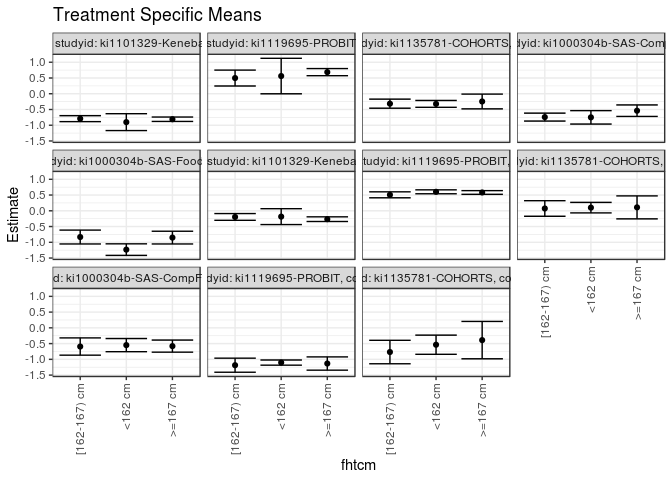

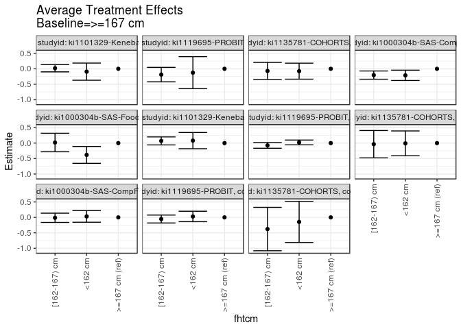

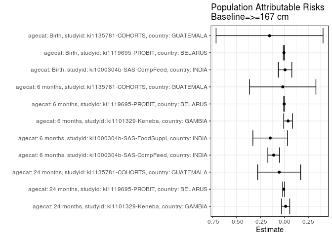

## Results Table

### Parameter: TSM

| agecat | studyid | country | intervention_level | baseline_level | estimate | ci_lower | ci_upper |
| --- | --- | --- | --- | --- | --- | --- | --- |
| Birth | ki1000304b-SAS-CompFeed | INDIA | >=167 cm | NA | -0.5800440 | -0.7719785 | -0.3881095 |
| Birth | ki1000304b-SAS-CompFeed | INDIA | <162 cm | NA | -0.5484572 | -0.7579455 | -0.3389690 |
| Birth | ki1000304b-SAS-CompFeed | INDIA | [162-167) cm | NA | -0.5932072 | -0.8673188 | -0.3190957 |
| Birth | ki1119695-PROBIT | BELARUS | >=167 cm | NA | -1.1331278 | -1.3441191 | -0.9221365 |
| Birth | ki1119695-PROBIT | BELARUS | <162 cm | NA | -1.1031981 | -1.1851878 | -1.0212084 |
| Birth | ki1119695-PROBIT | BELARUS | [162-167) cm | NA | -1.1861545 | -1.4091566 | -0.9631524 |
| Birth | ki1135781-COHORTS | GUATEMALA | >=167 cm | NA | -0.3898402 | -0.9830285 | 0.2033481 |
| Birth | ki1135781-COHORTS | GUATEMALA | <162 cm | NA | -0.5358440 | -0.8400948 | -0.2315932 |
| Birth | ki1135781-COHORTS | GUATEMALA | [162-167) cm | NA | -0.7677727 | -1.1401301 | -0.3954152 |
| 6 months | ki1000304b-SAS-CompFeed | INDIA | >=167 cm | NA | -0.5382821 | -0.7211470 | -0.3554171 |
| 6 months | ki1000304b-SAS-CompFeed | INDIA | <162 cm | NA | -0.7497528 | -0.9626143 | -0.5368913 |
| 6 months | ki1000304b-SAS-CompFeed | INDIA | [162-167) cm | NA | -0.7417375 | -0.8679603 | -0.6155147 |
| 6 months | ki1000304b-SAS-FoodSuppl | INDIA | >=167 cm | NA | -0.8510257 | -1.0536258 | -0.6484256 |
| 6 months | ki1000304b-SAS-FoodSuppl | INDIA | <162 cm | NA | -1.2328855 | -1.4166282 | -1.0491427 |
| 6 months | ki1000304b-SAS-FoodSuppl | INDIA | [162-167) cm | NA | -0.8327111 | -1.0527542 | -0.6126680 |
| 6 months | ki1101329-Keneba | GAMBIA | >=167 cm | NA | -0.2657103 | -0.3396674 | -0.1917532 |
| 6 months | ki1101329-Keneba | GAMBIA | <162 cm | NA | -0.1849688 | -0.4367488 | 0.0668113 |
| 6 months | ki1101329-Keneba | GAMBIA | [162-167) cm | NA | -0.1953714 | -0.3023450 | -0.0883979 |
| 6 months | ki1119695-PROBIT | BELARUS | >=167 cm | NA | 0.5813962 | 0.5222842 | 0.6405082 |
| 6 months | ki1119695-PROBIT | BELARUS | <162 cm | NA | 0.6027796 | 0.5402402 | 0.6653190 |
| 6 months | ki1119695-PROBIT | BELARUS | [162-167) cm | NA | 0.5069579 | 0.4122600 | 0.6016559 |
| 6 months | ki1135781-COHORTS | GUATEMALA | >=167 cm | NA | 0.1085175 | -0.2565380 | 0.4735730 |
| 6 months | ki1135781-COHORTS | GUATEMALA | <162 cm | NA | 0.1001860 | -0.0662969 | 0.2666688 |
| 6 months | ki1135781-COHORTS | GUATEMALA | [162-167) cm | NA | 0.0731858 | -0.1738967 | 0.3202684 |
| 24 months | ki1101329-Keneba | GAMBIA | >=167 cm | NA | -0.8096318 | -0.8794547 | -0.7398089 |
| 24 months | ki1101329-Keneba | GAMBIA | <162 cm | NA | -0.9016679 | -1.1695518 | -0.6337841 |
| 24 months | ki1101329-Keneba | GAMBIA | [162-167) cm | NA | -0.7908817 | -0.8854841 | -0.6962794 |
| 24 months | ki1119695-PROBIT | BELARUS | >=167 cm | NA | 0.6861849 | 0.5733277 | 0.7990420 |
| 24 months | ki1119695-PROBIT | BELARUS | <162 cm | NA | 0.5615838 | -0.0019391 | 1.1251066 |
| 24 months | ki1119695-PROBIT | BELARUS | [162-167) cm | NA | 0.4981740 | 0.2459996 | 0.7503483 |
| 24 months | ki1135781-COHORTS | GUATEMALA | >=167 cm | NA | -0.2458309 | -0.4804211 | -0.0112407 |
| 24 months | ki1135781-COHORTS | GUATEMALA | <162 cm | NA | -0.3222722 | -0.4311034 | -0.2134411 |
| 24 months | ki1135781-COHORTS | GUATEMALA | [162-167) cm | NA | -0.3151942 | -0.4593729 | -0.1710154 |

### Parameter: E(Y)

| agecat | studyid | country | intervention_level | baseline_level | estimate | ci_lower | ci_upper |
| --- | --- | --- | --- | --- | --- | --- | --- |
| Birth | ki1000304b-SAS-CompFeed | INDIA | NA | NA | -0.5733486 | -0.7681703 | -0.3785268 |
| Birth | ki1119695-PROBIT | BELARUS | NA | NA | -1.1379626 | -1.3471426 | -0.9287826 |
| Birth | ki1135781-COHORTS | GUATEMALA | NA | NA | -0.5450521 | -0.7653906 | -0.3247135 |
| 6 months | ki1000304b-SAS-CompFeed | INDIA | NA | NA | -0.6502726 | -0.7957520 | -0.5047932 |
| 6 months | ki1000304b-SAS-FoodSuppl | INDIA | NA | NA | -0.9997844 | -1.1172238 | -0.8823449 |
| 6 months | ki1101329-Keneba | GAMBIA | NA | NA | -0.2272039 | -0.2854286 | -0.1689793 |
| 6 months | ki1119695-PROBIT | BELARUS | NA | NA | 0.5791961 | 0.5216790 | 0.6367132 |
| 6 months | ki1135781-COHORTS | GUATEMALA | NA | NA | 0.0909226 | -0.0348636 | 0.2167089 |
| 24 months | ki1101329-Keneba | GAMBIA | NA | NA | -0.7963776 | -0.8498028 | -0.7429525 |
| 24 months | ki1119695-PROBIT | BELARUS | NA | NA | 0.6785166 | 0.5638515 | 0.7931818 |
| 24 months | ki1135781-COHORTS | GUATEMALA | NA | NA | -0.3002632 | -0.3780672 | -0.2224591 |

### Parameter: ATE

| agecat | studyid | country | intervention_level | baseline_level | estimate | ci_lower | ci_upper |
| --- | --- | --- | --- | --- | --- | --- | --- |
| Birth | ki1000304b-SAS-CompFeed | INDIA | >=167 cm | >=167 cm | 0.0000000 | 0.0000000 | 0.0000000 |
| Birth | ki1000304b-SAS-CompFeed | INDIA | <162 cm | >=167 cm | 0.0315868 | -0.1565647 | 0.2197382 |
| Birth | ki1000304b-SAS-CompFeed | INDIA | [162-167) cm | >=167 cm | -0.0131632 | -0.1627504 | 0.1364240 |
| Birth | ki1119695-PROBIT | BELARUS | >=167 cm | >=167 cm | 0.0000000 | 0.0000000 | 0.0000000 |
| Birth | ki1119695-PROBIT | BELARUS | <162 cm | >=167 cm | 0.0299297 | -0.1389683 | 0.1988277 |
| Birth | ki1119695-PROBIT | BELARUS | [162-167) cm | >=167 cm | -0.0530267 | -0.1812786 | 0.0752252 |
| Birth | ki1135781-COHORTS | GUATEMALA | >=167 cm | >=167 cm | 0.0000000 | 0.0000000 | 0.0000000 |
| Birth | ki1135781-COHORTS | GUATEMALA | <162 cm | >=167 cm | -0.1460038 | -0.8125515 | 0.5205439 |
| Birth | ki1135781-COHORTS | GUATEMALA | [162-167) cm | >=167 cm | -0.3779325 | -1.0801053 | 0.3242404 |
| 6 months | ki1000304b-SAS-CompFeed | INDIA | >=167 cm | >=167 cm | 0.0000000 | 0.0000000 | 0.0000000 |
| 6 months | ki1000304b-SAS-CompFeed | INDIA | <162 cm | >=167 cm | -0.2114708 | -0.3782123 | -0.0447292 |
| 6 months | ki1000304b-SAS-CompFeed | INDIA | [162-167) cm | >=167 cm | -0.2034555 | -0.3362210 | -0.0706900 |
| 6 months | ki1000304b-SAS-FoodSuppl | INDIA | >=167 cm | >=167 cm | 0.0000000 | 0.0000000 | 0.0000000 |
| 6 months | ki1000304b-SAS-FoodSuppl | INDIA | <162 cm | >=167 cm | -0.3818598 | -0.6553753 | -0.1083442 |
| 6 months | ki1000304b-SAS-FoodSuppl | INDIA | [162-167) cm | >=167 cm | 0.0183146 | -0.2812167 | 0.3178458 |
| 6 months | ki1101329-Keneba | GAMBIA | >=167 cm | >=167 cm | 0.0000000 | 0.0000000 | 0.0000000 |
| 6 months | ki1101329-Keneba | GAMBIA | <162 cm | >=167 cm | 0.0807416 | -0.1817477 | 0.3432308 |
| 6 months | ki1101329-Keneba | GAMBIA | [162-167) cm | >=167 cm | 0.0703389 | -0.0594676 | 0.2001453 |
| 6 months | ki1119695-PROBIT | BELARUS | >=167 cm | >=167 cm | 0.0000000 | 0.0000000 | 0.0000000 |
| 6 months | ki1119695-PROBIT | BELARUS | <162 cm | >=167 cm | 0.0213834 | -0.0558814 | 0.0986482 |
| 6 months | ki1119695-PROBIT | BELARUS | [162-167) cm | >=167 cm | -0.0744382 | -0.1669440 | 0.0180675 |
| 6 months | ki1135781-COHORTS | GUATEMALA | >=167 cm | >=167 cm | 0.0000000 | 0.0000000 | 0.0000000 |
| 6 months | ki1135781-COHORTS | GUATEMALA | <162 cm | >=167 cm | -0.0083315 | -0.4097562 | 0.3930932 |
| 6 months | ki1135781-COHORTS | GUATEMALA | [162-167) cm | >=167 cm | -0.0353317 | -0.4771913 | 0.4065280 |
| 24 months | ki1101329-Keneba | GAMBIA | >=167 cm | >=167 cm | 0.0000000 | 0.0000000 | 0.0000000 |
| 24 months | ki1101329-Keneba | GAMBIA | <162 cm | >=167 cm | -0.0920362 | -0.3691688 | 0.1850964 |
| 24 months | ki1101329-Keneba | GAMBIA | [162-167) cm | >=167 cm | 0.0187500 | -0.0991208 | 0.1366209 |
| 24 months | ki1119695-PROBIT | BELARUS | >=167 cm | >=167 cm | 0.0000000 | 0.0000000 | 0.0000000 |
| 24 months | ki1119695-PROBIT | BELARUS | <162 cm | >=167 cm | -0.1246011 | -0.6427983 | 0.3935961 |
| 24 months | ki1119695-PROBIT | BELARUS | [162-167) cm | >=167 cm | -0.1880109 | -0.4217000 | 0.0456782 |
| 24 months | ki1135781-COHORTS | GUATEMALA | >=167 cm | >=167 cm | 0.0000000 | 0.0000000 | 0.0000000 |
| 24 months | ki1135781-COHORTS | GUATEMALA | <162 cm | >=167 cm | -0.0764413 | -0.3350728 | 0.1821901 |
| 24 months | ki1135781-COHORTS | GUATEMALA | [162-167) cm | >=167 cm | -0.0693632 | -0.3450207 | 0.2062942 |

### Parameter: PAR

| agecat | studyid | country | intervention_level | baseline_level | estimate | ci_lower | ci_upper |
| --- | --- | --- | --- | --- | --- | --- | --- |
| Birth | ki1000304b-SAS-CompFeed | INDIA | >=167 cm | NA | 0.0066954 | -0.0640229 | 0.0774138 |
| Birth | ki1119695-PROBIT | BELARUS | >=167 cm | NA | -0.0048348 | -0.0115881 | 0.0019185 |
| Birth | ki1135781-COHORTS | GUATEMALA | >=167 cm | NA | -0.1552119 | -0.7138685 | 0.4034447 |
| 6 months | ki1000304b-SAS-CompFeed | INDIA | >=167 cm | NA | -0.1119906 | -0.1732332 | -0.0507480 |
| 6 months | ki1000304b-SAS-FoodSuppl | INDIA | >=167 cm | NA | -0.1487587 | -0.3294283 | 0.0319110 |
| 6 months | ki1101329-Keneba | GAMBIA | >=167 cm | NA | 0.0385064 | -0.0072815 | 0.0842942 |
| 6 months | ki1119695-PROBIT | BELARUS | >=167 cm | NA | -0.0022001 | -0.0073380 | 0.0029378 |
| 6 months | ki1135781-COHORTS | GUATEMALA | >=167 cm | NA | -0.0175949 | -0.3641282 | 0.3289384 |
| 24 months | ki1101329-Keneba | GAMBIA | >=167 cm | NA | 0.0132541 | -0.0293745 | 0.0558828 |
| 24 months | ki1119695-PROBIT | BELARUS | >=167 cm | NA | -0.0076683 | -0.0178492 | 0.0025126 |
| 24 months | ki1135781-COHORTS | GUATEMALA | >=167 cm | NA | -0.0544322 | -0.2786587 | 0.1697942 |